# Assignment: AdaBoost for Regression

SOLUTION (instructor copy)

## The problem

A small data set has one input $x$ and a numeric response $y$:

| $x$ | 1 | 2 | 3 | 4 | 5 | 6 | 7 | 8 |
| --- | --- | --- | --- | --- | --- | --- | --- | --- |
| $y$ | 2 | 5 | 5 | 5 | 7 | 6 | 10 | 9 |

You will build an **AdaBoost.R2** model with **three regression stumps**, using

- square loss: $L_i = \left(\dfrac{|y_i-\hat y_i|}{D}\right)^2$ where $D=\max_i|y_i-\hat y_i|$
- learning rate $\eta = 1$
- starting weights $w_i = 1/8$

**You do not have to build the stumps.** They are given (they are the best weighted-SSE splits found in each round):

| Stump | Rule |
| --- | --- |
| $h_1(x)$ | $5.00$ if $x \le 6.5$, otherwise $9.50$ |
| $h_2(x)$ | $2.00$ if $x \le 1.5$, otherwise $6.76$ |
| $h_3(x)$ | $3.59$ if $x \le 4.5$, otherwise $8.61$ |

Recall, for each round $m$:

$$\bar L_m=\sum_i w_iL_i,\qquad \beta_m=\frac{\bar L_m}{1-\bar L_m},\qquad \alpha_m=\eta\ln\frac1{\beta_m},\qquad w_i^{new}\propto w_i\,\beta_m^{\,\eta(1-L_i)}$$

and the final model $H(x)$ is the **weighted median** of $h_1(x),h_2(x),h_3(x)$ with weights $\alpha_1,\alpha_2,\alpha_3$.

## Questions

**Q1 (20 pts), Round 1.**

1. Write the starting weights. (b) Compute the predictions of $h_1$ and the absolute errors $|y_i-\hat y_i|$. (c) Find $D_1$ and the loss $L_i$ of every row. (d) Compute $\bar L_1$, $\beta_1$ and $\alpha_1$. (e) Compute the new weights (before and after normalizing). Which row now has the largest weight?

**Q2 (25 pts), Round 2.** Repeat Q1 (b) to (e) for $h_2$, using the weights you found in Q1(e).

**Q3 (15 pts), Round 3.** For $h_3$, using the weights from Q2, compute $D_3$, $\bar L_3$, $\beta_3$ and $\alpha_3$. (You do not need the new weights.)

**Q4 (20 pts), Final model.**

1. Write the final model $H(x)$ in terms of $h_m$ and $\alpha_m$.
2. Compute $H(2)$ and $H(7)$, showing the sorted predictions and the cumulative voting power.
3. Compute $H(x)$ for all 8 rows and the training MSE. Compare it with the MSE of $h_1$ alone.

**Q5 (10 pts), Plots.** Draw (i) three plots, one per stump, with the point size proportional to the weight used to fit that stump, and (ii) one plot of the final model $H(x)$ on top of the data.

**Q6 (10 pts), Concept questions.**

1. Which row has the largest error in Round 1, and what happens to its weight? Why?
2. A stump has $\bar L=0.55$. What are $\beta$ and $\alpha$? What should the algorithm do?
3. Redo $\alpha_1$ with $\eta=0.5$, and compute the raw new weight of the row with $x=2$. What does a smaller $\eta$ do?
4. Why does AdaBoost.R2 combine stumps with a weighted **median** instead of a weighted mean?

# Solution

## Q1: Round 1

**(a)** Starting weights: $w_i = 1/8 = 0.125$ for every row.

**(b)–(c)** Predictions, errors and losses of $h_1$:

| x | y | w1 | h1(x) | \|y − ŷ\| | L |
| --- | --- | --- | --- | --- | --- |
| 1 | 2 | 0.125 | 5.0 | 3.0 | 1.0000 |
| 2 | 5 | 0.125 | 5.0 | 0.0 | 0.0000 |
| 3 | 5 | 0.125 | 5.0 | 0.0 | 0.0000 |
| 4 | 5 | 0.125 | 5.0 | 0.0 | 0.0000 |
| 5 | 7 | 0.125 | 5.0 | 2.0 | 0.4444 |
| 6 | 6 | 0.125 | 5.0 | 1.0 | 0.1111 |
| 7 | 10 | 0.125 | 9.5 | 0.5 | 0.0278 |
| 8 | 9 | 0.125 | 9.5 | 0.5 | 0.0278 |

The largest error is $D_1 = 3.00$ (at $x=1$), so that row has $L=1$ and every other loss is $(|y-\hat y|/3)^2$.

**(d)**

$$\bar L_1=\sum_i w_iL_i = 0.125\,(1.0000 + 0.4444 + 0.1111 + 0.0278 + 0.0278) = 0.2014$$

$$\beta_1=\frac{0.2014}{1-0.2014}=0.2522 \qquad \alpha_1=\ln\frac{1}{0.2522}=1.378$$

**(e)** New weights $w\cdot\beta_1^{\,1-L}$, then divide by the total:

| x | y | w1 | L | raw w2 | w2 |
| --- | --- | --- | --- | --- | --- |
| 1 | 2 | 0.125 | 1.0000 | 0.1250 | 0.3290 |
| 2 | 5 | 0.125 | 0.0000 | 0.0315 | 0.0830 |
| 3 | 5 | 0.125 | 0.0000 | 0.0315 | 0.0830 |
| 4 | 5 | 0.125 | 0.0000 | 0.0315 | 0.0830 |
| 5 | 7 | 0.125 | 0.4444 | 0.0581 | 0.1530 |
| 6 | 6 | 0.125 | 0.1111 | 0.0367 | 0.0967 |
| 7 | 10 | 0.125 | 0.0278 | 0.0328 | 0.0862 |
| 8 | 9 | 0.125 | 0.0278 | 0.0328 | 0.0862 |

Total of the raw weights $=0.3799$. The largest weight is now at $x=1$ ($w_2=0.3290$).

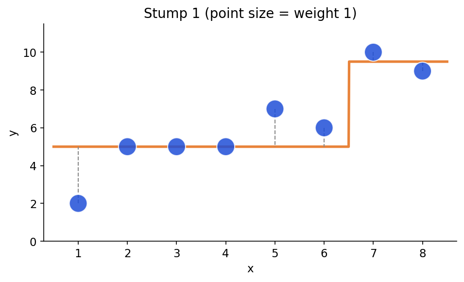

## Q2: Round 2

| x | y | w2 | h2(x) | \|y − ŷ\| | L | w · L |
| --- | --- | --- | --- | --- | --- | --- |
| 1 | 2 | 0.3290 | 2.00 | 0.00 | 0.0000 | 0.00000 |
| 2 | 5 | 0.0830 | 6.76 | 1.76 | 0.2951 | 0.02448 |
| 3 | 5 | 0.0830 | 6.76 | 1.76 | 0.2951 | 0.02448 |
| 4 | 5 | 0.0830 | 6.76 | 1.76 | 0.2951 | 0.02448 |
| 5 | 7 | 0.1530 | 6.76 | 0.24 | 0.0055 | 0.00084 |
| 6 | 6 | 0.0967 | 6.76 | 0.76 | 0.0550 | 0.00532 |
| 7 | 10 | 0.0862 | 6.76 | 3.24 | 1.0000 | 0.08620 |
| 8 | 9 | 0.0862 | 6.76 | 2.24 | 0.4780 | 0.04120 |

$D_2=3.24$ (at $x=7$). $\bar L_2=\sum w_iL_i=0.2070$

$$\beta_2=\frac{0.2070}{1-0.2070}=0.2610 \qquad \alpha_2=\ln\frac{1}{0.2610}=1.343$$

New weights:

| x | y | w2 | L | raw w3 | w3 |
| --- | --- | --- | --- | --- | --- |
| 1 | 2 | 0.3290 | 0.0000 | 0.0859 | 0.2267 |
| 2 | 5 | 0.0830 | 0.2951 | 0.0322 | 0.0850 |
| 3 | 5 | 0.0830 | 0.2951 | 0.0322 | 0.0850 |
| 4 | 5 | 0.0830 | 0.2951 | 0.0322 | 0.0850 |
| 5 | 7 | 0.1530 | 0.0055 | 0.0402 | 0.1062 |
| 6 | 6 | 0.0967 | 0.0550 | 0.0272 | 0.0717 |
| 7 | 10 | 0.0862 | 1.0000 | 0.0862 | 0.2275 |
| 8 | 9 | 0.0862 | 0.4780 | 0.0428 | 0.1129 |

Total of the raw weights $=0.3788$.

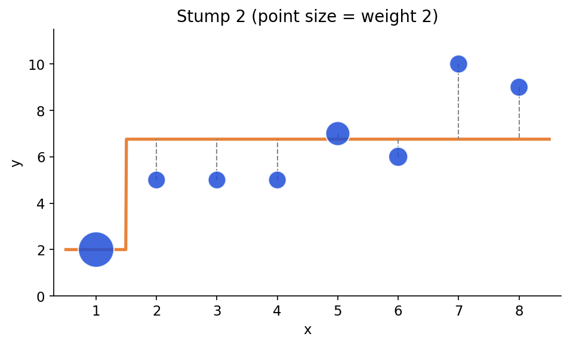

## Q3: Round 3

| x | y | w3 | h3(x) | \|y − ŷ\| | L | w · L |
| --- | --- | --- | --- | --- | --- | --- |
| 1 | 2 | 0.2267 | 3.59 | 1.59 | 0.3711 | 0.08413 |
| 2 | 5 | 0.0850 | 3.59 | 1.41 | 0.2918 | 0.02480 |
| 3 | 5 | 0.0850 | 3.59 | 1.41 | 0.2918 | 0.02480 |
| 4 | 5 | 0.0850 | 3.59 | 1.41 | 0.2918 | 0.02480 |
| 5 | 7 | 0.1062 | 8.61 | 1.61 | 0.3805 | 0.04042 |
| 6 | 6 | 0.0717 | 8.61 | 2.61 | 1.0000 | 0.07173 |
| 7 | 10 | 0.2275 | 8.61 | 1.39 | 0.2836 | 0.06454 |
| 8 | 9 | 0.1129 | 8.61 | 0.39 | 0.0223 | 0.00252 |

$D_3=2.61$ (at $x=6$). $\bar L_3=\sum w_iL_i=0.3377$

$$\beta_3=\frac{0.3377}{1-0.3377}=0.5100 \qquad \alpha_3=\ln\frac{1}{0.5100}=0.673$$

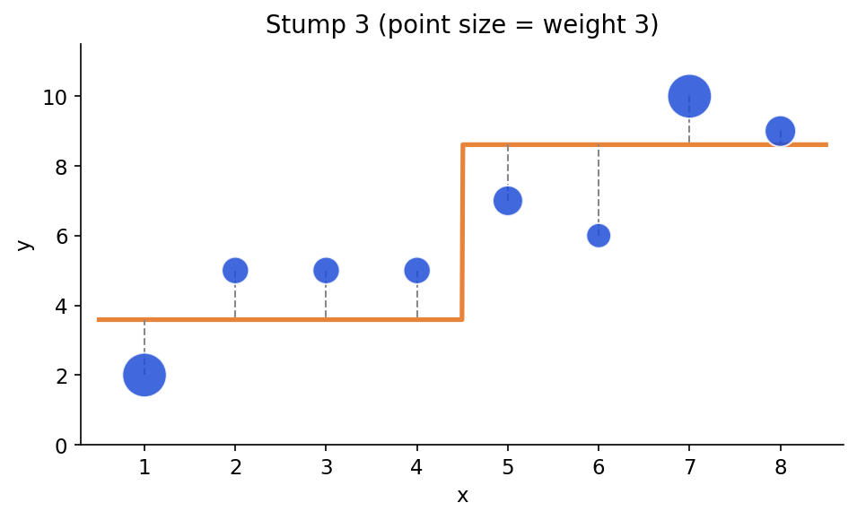

## Q4: Final model

**(a)** $H(x)=\text{weighted median}\{h_1(x),h_2(x),h_3(x)\}$ with weights $\alpha_1,\alpha_2,\alpha_3$.

With the values above: $\alpha_1=1.378$, $\alpha_2=1.343$, $\alpha_3=0.673$ (total $3.394$, half $=1.697$).

**(b)** Sort the three predictions, add up the voting powers, and stop at the first cumulative value $\ge$ half the total.

**x = 2** (half of total = 1.697)

| Sorted prediction | From | α | Cumulative α |
| --- | --- | --- | --- |
| 3.59 | h3 | 0.673 | 0.673 |
| 5.00 | h1 | 1.378 | 2.051 |
| 6.76 | h2 | 1.343 | 3.394 |

$H(2)=5.00$

**x = 7** (half of total = 1.697)

| Sorted prediction | From | α | Cumulative α |
| --- | --- | --- | --- |
| 6.76 | h2 | 1.343 | 1.343 |
| 8.61 | h3 | 0.673 | 2.016 |
| 9.50 | h1 | 1.378 | 3.394 |

$H(7)=8.61$

**(c)**

| x | y | h1 | h2 | h3 | H(x) | y − H(x) |
| --- | --- | --- | --- | --- | --- | --- |
| 1 | 2 | 5.0 | 2.00 | 3.59 | 3.59 | -1.59 |
| 2 | 5 | 5.0 | 6.76 | 3.59 | 5.00 | 0.00 |
| 3 | 5 | 5.0 | 6.76 | 3.59 | 5.00 | 0.00 |
| 4 | 5 | 5.0 | 6.76 | 3.59 | 5.00 | 0.00 |
| 5 | 7 | 5.0 | 6.76 | 8.61 | 6.76 | 0.24 |
| 6 | 6 | 5.0 | 6.76 | 8.61 | 6.76 | -0.76 |
| 7 | 10 | 9.5 | 6.76 | 8.61 | 8.61 | 1.39 |
| 8 | 9 | 9.5 | 6.76 | 8.61 | 8.61 | 0.39 |

MSE of $h_1$ alone $=1.812$; MSE of $H$ $=0.656$. The 3-stump model reduces the training error.

## Q5: Plots

All three stumps (point size = the weight used to fit that stump; dashed lines = errors):

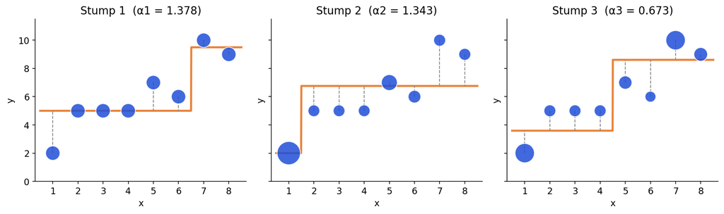

Final model:

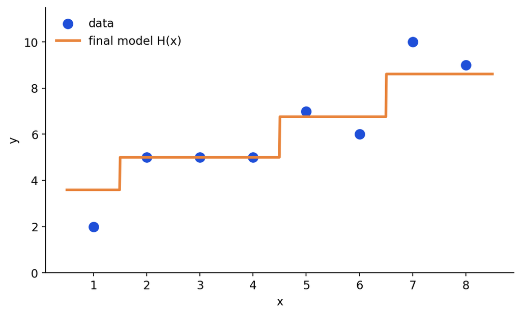

Building up the model one stump at a time:

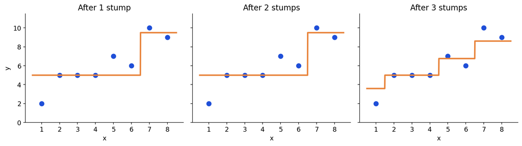

## Q6: Concept questions

**(a)** The largest Round-1 error is at $x=1$ ($y=2$, $h_1=5.0$, error $3$), so $L=1$. Its raw weight is multiplied by $\beta_1^{0}=1$ while every other row is multiplied by $\beta_1^{1-L}<1$. After normalizing, its weight rises from $0.125$ to $0.329$. **Rows that the stump fits badly get more weight, so the next stump focuses on them.**

**(b)** $\beta=0.55/0.45=1.222>1$, so $\alpha=\ln(1/\beta)=-0.201<0$. The stump is worse than chance, so the algorithm **stops** (or discards that stump).

**(c)** With $\eta=0.5$: $\alpha_1=0.5\ln(1/0.2522)=0.689$ (instead of 1.378). The raw weight at $x=2$ (with $L=0$) is $0.125\cdot0.2522^{0.5}=0.0628$ (instead of 0.0315). A smaller learning rate gives smaller voting powers and **gentler weight changes**, so more stumps are needed; it learns more slowly but is usually more stable.

**(d)** A weighted mean can be pulled far away by one stump with a wild prediction (especially one with a big voting power). The weighted median takes the prediction that the **majority of the voting power** agrees on, so it is robust to a single bad stump.

## Suggested grading

| Part | Points | Key checks |
| --- | --- | --- |
| Q1 | 20 | $D_1$, losses, $\bar L_1$, $\alpha_1$, normalized weights |
| Q2 | 25 | Uses $w_2$ (not the original weights), $\bar L_2$, $\alpha_2$, new weights |
| Q3 | 15 | $\bar L_3$, $\alpha_3$ |
| Q4 | 20 | Weighted-median procedure shown, $H(2)$, $H(7)$, MSE comparison |
| Q5 | 10 | Point sizes vary by weight; final step function drawn |
| Q6 | 10 | Reasoning for (a)–(d) |

**NoteInstructor check: the given stumps really are the best weighted-SSE splits**

| Round | Best split: x ≤ | Left mean | Right mean | Given stump |
| --- | --- | --- | --- | --- |
| 1 | 6.5 | 5.00 | 9.50 | x ≤ 6.5: 5.0 / 9.5 |
| 2 | 1.5 | 2.00 | 6.76 | x ≤ 1.5: 2.0 / 6.76 |
| 3 | 4.5 | 3.59 | 8.61 | x ≤ 4.5: 3.59 / 8.61 |